# Modelos Aninhados no R

Rodrigo F. Pizzinato

2023-01-31

```r
library(tidyverse)
library(broom)
library(rsample)
library(corrr)
library(paletteer) # Paleta de cores
library(gapminder) # dataset a ser utilizado
library(geomtextpath)
library(ggpubr)

ggplot2::theme_set(
  theme_light() +
    theme(strip.text = element_text(face = "bold", size = 10),
          strip.background = element_rect(fill = "#74bd6c"),
          panel.grid = element_blank(),
          axis.line = element_line(linewidth = 1, color = "#74bd6c"),
          axis.text = element_text(face = "bold", colour = "#072e10"))
  )

df <- gapminder %>%
  set_names(c("pais","continente","ano","exp_vida","populacao","pib_per_cap"))
```

## 0.1 Introdução

Neste post irei demonstrar como utilizar a abordagem de nested models (modelos aninhados) no R, que consiste basicamente em dividir os dados por alguma variável categórica, aplicar um modelo estatístico e combinar os resultados obtidos em uma tabela.

Para este exemplo será necessário somente alguns pacotes:

- O `tidyverse` servirá como o framework básico para manipulação de dados.
- O `broom` é utilizado para transformar os resultados dos modelos no format **tidy**.
- O `gapminder` é de onde vem a base de dados.
- O `rsample` fornece a função para modelagem bootstrap.
- O `corrr` fornece funções para calcular matrizes de correlação.

## 0.2 Breve análise exploratória

Primeiro, é feito o gráfico de correlação das variáveis, na qual é possível identificar que as variáveis expectativa de vida e ano tem um correlação média positiva, ou seja, a primeira tende a aumentar com o passar dos anos.  
Já o produto per capita se correlaciona mais fortemente com a expectativa de vida.

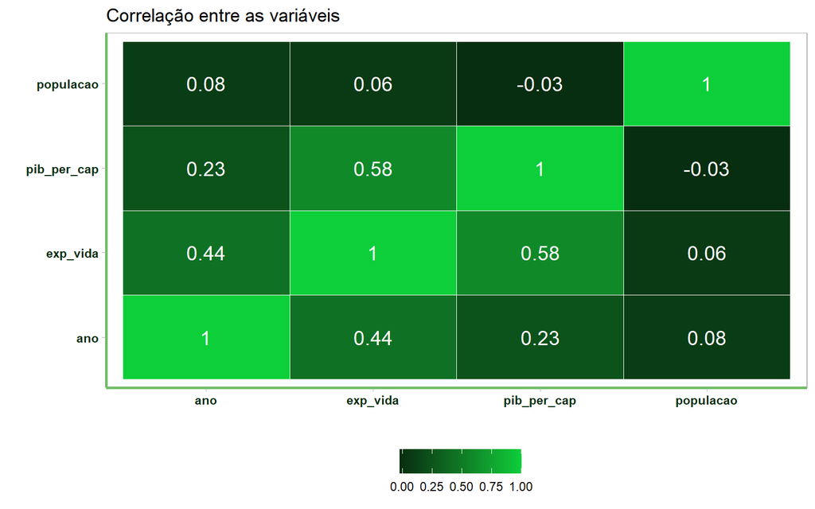

```r
df %>%
  select(where(is.numeric)) %>%
  corrr::correlate(diagonal = 1) %>%
  corrr::rearrange() %>%
  corrr::stretch() %>%
  ggplot(aes(x,y, fill = r)) +
  geom_tile(color = "white") +
  geom_text(aes(label = round(r,2)),
            color = "white",
            size = 5,
            show.legend = FALSE) +
  scale_fill_gradient(low = "#072e10", high = "#0ccf3a") +
  labs(x='',y='', fill='',
       title = "Correlação entre as variáveis") +
  theme(legend.position = "bottom",
        legend.direction = "horizontal")
```

A expectativa de vida também tem uma tendência crescente em todos os continentes, apesar de estarem em níveis bem diferentes.

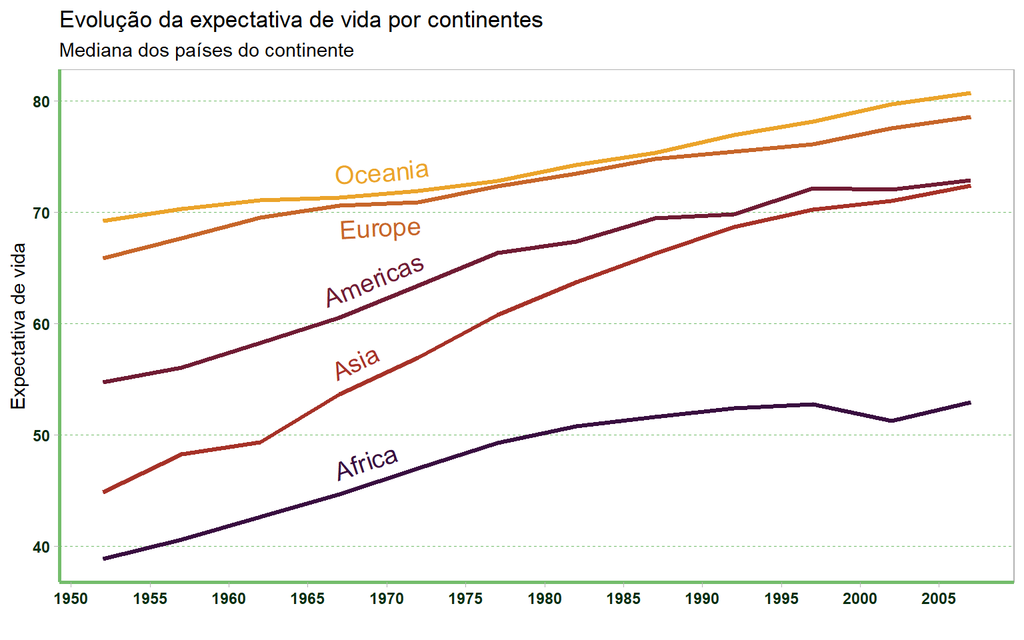

```r
df %>%
  group_by(continente, ano) %>%
  summarize(exp_vida = median(exp_vida),
            .groups = "drop") %>%
  mutate(vjust = if_else(continente == "Europe", 1.5, -0.5)) %>%
  ggplot(aes(ano, exp_vida, color = continente)) +
  geom_textline(aes(label = continente, vjust = vjust),
                size        = 5,
                hjust       = 0.3,
                linewidth   = 1.2,
                show.legend = FALSE) +
  #geom_line(size = 1.2) +
  scale_color_paletteer_d("NineteenEightyR::sunset3") +
  scale_x_continuous(breaks = seq(1950, 2010, 5)) +
  labs(x='', y='Expectativa de vida', color = '',
       title = "Evolução da expectativa de vida por continentes",
       subtitle = "Mediana dos países do continente") +
  theme(legend.position = "bottom",
        panel.grid.major.y = element_line(linewidth = 0.2, linetype = 2, color = "#74bd6c"))
```

Neste último gráfico, é possível ver que o produto per capita se relaciona positivamente com a expectativa de vida. Porém, uma regressão linear indica coeficientes diferentes para cada continente.

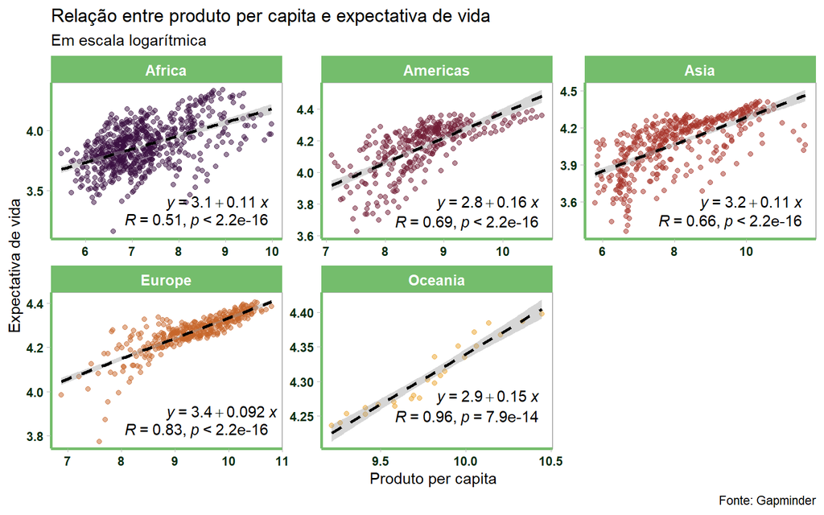

```r
df %>%
  ggplot(aes(log(pib_per_cap), log(exp_vida), colour = continente)) +
  geom_point(alpha = 0.5, show.legend = FALSE) +
  geom_smooth(method = "lm", show.legend = FALSE,
              colour = "black", lty = 2) +
  scale_color_paletteer_d("NineteenEightyR::sunset3") +
  facet_wrap(vars(continente), scales = "free") +
  ggpubr::stat_regline_equation(color = "black", label.x.npc = 0.5, label.y.npc = "bottom") +
  ggpubr::stat_cor(color = "black", label.x.npc = 0.3, label.y.npc = 0.1) +
  labs(x='Produto per capita', y='Expectativa de vida',
       title = "Relação entre produto per capita e expectativa de vida",
       subtitle = "Em escala logarítmica",
       caption = "Fonte: Gapminder")
```

## 0.3 Estimação dos modelos

A idéia aqui é estimar modelos de regressão linear para cada continente em realçao ao tempo (coluna **year**), de modo que possamos obter coeficientes para cada um deles em particular. No entanto, ao invés de utilizar somente um modelo de regressão para cada continente, irei estimar diversos modelos através de um método chamado bootstrap.  
Dado que a regressão linear se basea em diversos pressupostos, como a **normalidade** dos erros, **homocedasticidade** da variância e ausência de **multicolinearidade**.  
A ausência desses pressupostos levam, geralmente, a incosistências na estimação dos coeficientes ou dos erros padrão. A estimação por bootstrap não se baseia nesses pressupostos. Nela não há suposição de quem os advém de uma distribuição específica.  
Nos dados é aplicado um processo de reamostragem com substituição, na qual são construidos diversos conjuntos de dados (nesse caso são feitos 1000 conjuntos) e neles são estimados os coeficientes.

```r
tictoc::tic()
df_models <- df %>%
  nest(-c(continente)) %>%
  mutate(lm_mod = map(data, ~ reg_intervals(exp_vida ~ ano,
                                            data     = .x,
                                            model_fn = "lm",
                                            keep_reps = TRUE,
                                            type     = "percentile",
                                            times    = 1000,
                                            alpha    = 0.02)))
tictoc::toc()
```

```
## 41.69 sec elapsed
```

```r
df_models
```

```
## # A tibble: 5 x 3
##   continente data               lm_mod
##   <fct>      <list>             <list>
## 1 Asia       <tibble [396 x 5]> <tibble [1 x 7]>
## 2 Europe     <tibble [360 x 5]> <tibble [1 x 7]>
## 3 Africa     <tibble [624 x 5]> <tibble [1 x 7]>
## 4 Americas   <tibble [300 x 5]> <tibble [1 x 7]>
## 5 Oceania    <tibble [24 x 5]>  <tibble [1 x 7]>
```

Como os valores dos parâmetros para cada continente tem aproximadamente uma distribuição normal, faz sentido sumarizá-los através de uma média.

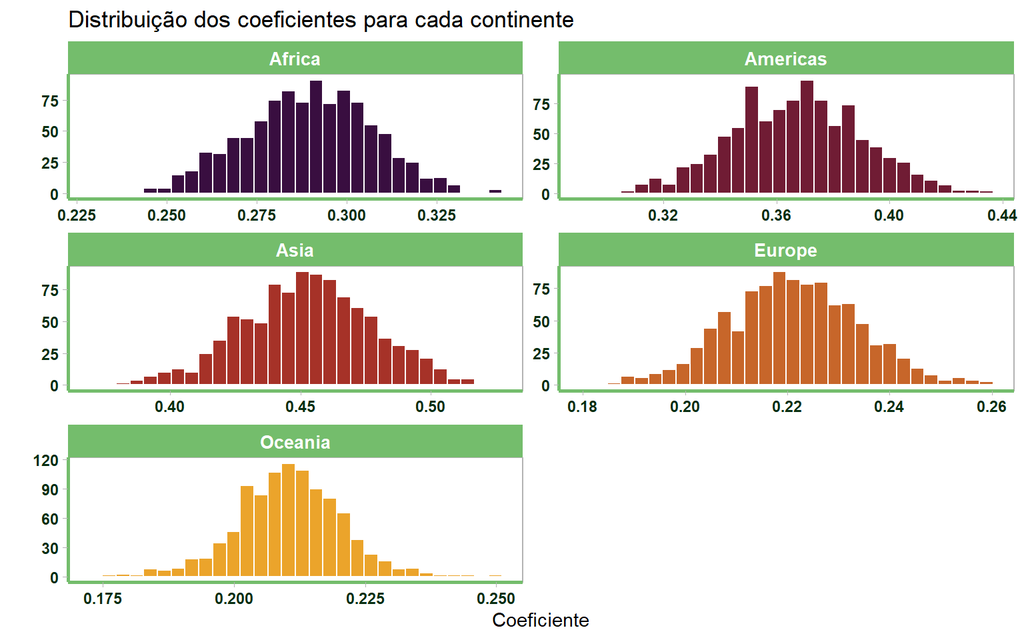

```r
df_models_unnested <- df_models %>%
  unnest(lm_mod) %>%
  unnest(.replicates)

df_models_unnested %>%
  ggplot(aes(estimate, fill = continente)) +
  geom_histogram(color = "white", show.legend = FALSE) +
  scale_fill_paletteer_d("NineteenEightyR::sunset3") +
  facet_wrap(vars(continente),
             scales = "free",
             ncol = 2) +
  labs(x='Coeficiente', y='', title = "Distribuição dos coeficientes para cada continente")
```

A coluna **lm_mod** contém o modelo com todas suas especificações.  
Para este exemplo, decidi utilizar como regressor somente a variável **ano**.  
O continente da ásia foi o que mais crescreu, em média, ao longo do tempo, como indicado no gráfico abaixo. Porém, teve o seu intervalo de confiança é o maior entre todos os continentes.

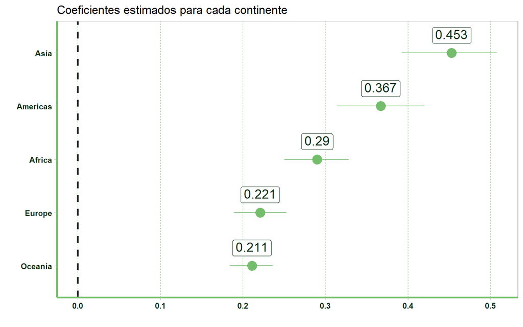

```r
df_models %>%
  unnest(lm_mod) %>%
  mutate(.estimate = round(.estimate, 3),
         term = str_c(continente),
         term = fct_reorder(term, .estimate)) %>%
  ggplot(aes(.estimate, term)) +
  geom_vline(xintercept = 0, lty = 2, size = 1, alpha = 0.8) +
  geom_pointrange(aes(xmin = .lower, xmax = .upper),
                 color = "#74bd6c", size = 1) +
  geom_label(aes(label = .estimate), size = 5, vjust = -0.6, color = "#072e10") +
  expand_limits(x = 0) +
  scale_x_continuous(labels = scales::comma) +
  labs(x='', y='',
       title = "Coeficientes estimados para cada continente") +
  theme(panel.grid.major.x = element_line(linewidth = 0.2, linetype = 2, color = "#74bd6c"))
```